# Lab Assignment Three: Extending Logistic Regression

## Course: Maching Learning in Python

## Semester: Fall 2023

### Team: Perceptron

### Authors

Brian Mendes (49243148)

Prashant Iyer (49352530)

Ritik K (49347408)

### Data Sources:

Credit Classification Dataset

Kaggle - https://www.kaggle.com/code/mohamedahmed10000/credit-score-eda-prediction-multi-class/input?select=train.csv

### Business Understanding:

Every financial institution (banks) runs on a credit-debit cycle. Credit defines the financial credibility of an individual. When trying to opt for a loan, get an upgraded credit-card, EMI's, offers etc., financial insitituions look at the credit score status for that individual. A good credit score indicates a strong and consistent financial history. However, this score changes from time to time, even every month. Moreover, the factors affecting the scores are not straightforward. The minute details of a financial history are considered. The factors include:

1. Occupation
2. Annual Income
3. Number of Bank Accounts
4. Number of Loans.
5. Type of loan
6. Delay in repayment
7. Number of Delays
8. Number of credit enquiries
9. Investments.
10. Payment Behaviour
11. Outstanding Debts
12. Total EMI's and many more.

Also, the scores can be very subjective to the nature and the way it is interpreted. This solution tries to consider all these factors for every customer per month and categorize the scores as **Good**, **Bad** & **Standard**. This helps the institutions keep a track of this information. This would be helpful in deciding the different schemes and offers that can be provided to the customers. Given a customer, has a good score, he can be given upgrades in this current credit amount or given better deals with loans which inturn would result in better earning for the banks.

Q. Can we predict anything better than just chance ot classify the credit scores as Good, Standard or Bad considering the available factors in order to classify the customer among different marketing and offer groups as a plan for next quarter changes?

```python
import pandas as pd
import numpy as np
import seaborn as sns
import matplotlib.pyplot as plt
import warnings
warnings.filterwarnings('ignore')
from scipy.special import expit
from sklearn.metrics import classification_report, accuracy_score
```

```python
df = pd.read_csv('credit_data.csv',low_memory=False)
```

```python
df.info()
```

```
<class 'pandas.core.frame.DataFrame'>
RangeIndex: 100000 entries, 0 to 99999
Data columns (total 28 columns):
 #   Column                    Non-Null Count   Dtype
---  ------                    --------------   -----
 0   ID                        100000 non-null  object
 1   Customer_ID               100000 non-null  object
 2   Month                     100000 non-null  object
 3   Name                      90015 non-null   object
 4   Age                       100000 non-null  object
 5   SSN                       100000 non-null  object
 6   Occupation                100000 non-null  object
 7   Annual_Income             100000 non-null  object
 8   Monthly_Inhand_Salary     84998 non-null   float64
 9   Num_Bank_Accounts         100000 non-null  int64
```

[output cut: 20 more lines]

```python
df.describe().T
```

|  | count | mean | std | min | 25% | 50% | 75% | max |
| --- | --- | --- | --- | --- | --- | --- | --- | --- |
| Monthly_Inhand_Salary | 84998.0 | 4194.170850 | 3183.686167 | 303.645417 | 1625.568229 | 3093.745000 | 5957.448333 | 15204.633333 |
| Num_Bank_Accounts | 100000.0 | 17.091280 | 117.404834 | -1.000000 | 3.000000 | 6.000000 | 7.000000 | 1798.000000 |
| Num_Credit_Card | 100000.0 | 22.474430 | 129.057410 | 0.000000 | 4.000000 | 5.000000 | 7.000000 | 1499.000000 |
| Interest_Rate | 100000.0 | 72.466040 | 466.422621 | 1.000000 | 8.000000 | 13.000000 | 20.000000 | 5797.000000 |
| Delay_from_due_date | 100000.0 | 21.068780 | 14.860104 | -5.000000 | 10.000000 | 18.000000 | 28.000000 | 67.000000 |
| Num_Credit_Inquiries | 98035.0 | 27.754251 | 193.177339 | 0.000000 | 3.000000 | 6.000000 | 9.000000 | 2597.000000 |
| Credit_Utilization_Ratio | 100000.0 | 32.285173 | 5.116875 | 20.000000 | 28.052567 | 32.305784 | 36.496663 | 50.000000 |
| Total_EMI_per_month | 100000.0 | 1403.118217 | 8306.041270 | 0.000000 | 30.306660 | 69.249473 | 161.224249 | 82331.000000 |

```python
df.isnull().sum()
```

```
ID                              0
Customer_ID                     0
Month                           0
Name                         9985
Age                             0
SSN                             0
Occupation                      0
Annual_Income                   0
Monthly_Inhand_Salary       15002
Num_Bank_Accounts               0
Num_Credit_Card                 0
Interest_Rate                   0
Num_of_Loan                     0
Type_of_Loan                11408
Delay_from_due_date             0
Num_of_Delayed_Payment       7002
Changed_Credit_Limit            0
Num_Credit_Inquiries         1965
Credit_Mix                      0
Outstanding_Debt                0
Credit_Utilization_Ratio        0
Credit_History_Age           9030
Payment_of_Min_Amount           0
Total_EMI_per_month             0
Amount_invested_monthly      4479
Payment_Behaviour               0
Monthly_Balance              1200
Credit_Score                    0
dtype: int64
```

```python
df.describe(exclude=np.number).T
```

|  | count | unique | top | freq |
| --- | --- | --- | --- | --- |
| ID | 100000 | 100000 | 0x1602 | 1 |
| Customer_ID | 100000 | 12500 | CUS_0xd40 | 8 |
| Month | 100000 | 8 | January | 12500 |
| Name | 90015 | 10139 | Langep | 44 |
| Age | 100000 | 1788 | 38 | 2833 |
| SSN | 100000 | 12501 | #F%$D@*&8 | 5572 |
| Occupation | 100000 | 16 | _______ | 7062 |
| Annual_Income | 100000 | 18940 | 36585.12 | 16 |
| Num_of_Loan | 100000 | 434 | 3 | 14386 |
| Type_of_Loan | 88592 | 6260 | Not Specified | 1408 |
| Num_of_Delayed_Payment | 92998 | 749 | 19 | 5327 |
| Changed_Credit_Limit | 100000 | 4384 | _ | 2091 |
| Credit_Mix | 100000 | 4 | Standard | 36479 |
| Outstanding_Debt | 100000 | 13178 | 1360.45 | 24 |
| Credit_History_Age | 90970 | 404 | 15 Years and 11 Months | 446 |
| Payment_of_Min_Amount | 100000 | 3 | Yes | 52326 |
| Amount_invested_monthly | 95521 | 91049 | __10000__ | 4305 |
| Payment_Behaviour | 100000 | 7 | Low_spent_Small_value_payments | 25513 |
| Monthly_Balance | 98800 | 98792 | __-333333333333333333333333333__ | 9 |
| Credit_Score | 100000 | 3 | Standard | 53174 |

```python
df.shape
```

```
(100000, 28)
```

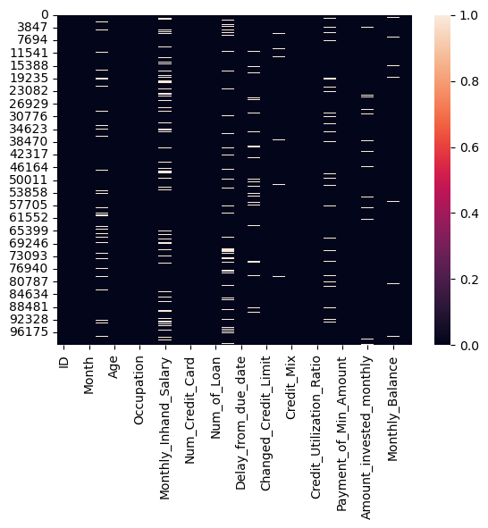

```python
sns.heatmap(df.isnull())
```

Data Analysis

```python
#Checking for duplicates in the dataset

df.duplicated().sum()
```

```
0
```

Factors not affecting the credit decision:

1. Name
2. SSN
3. ID

Only having one unique indetifier **Customer ID** is enough for identifying the Customers. The other redundant columns can be got rid of.

```python
#Drop Name and Age

df.drop(columns = ['Name','SSN','ID'],inplace=True)
```

```python
df
```

|  | Customer_ID | Month | Age | Occupation | Annual_Income | Monthly_Inhand_Salary | Num_Bank_Accounts | Num_Credit_Card | Interest_Rate | Num_of_Loan | ... | Credit_Mix | Outstanding_Debt | Credit_Utilization_Ratio | Credit_History_Age | Payment_of_Min_Amount | Total_EMI_per_month | Amount_invested_monthly | Payment_Behaviour | Monthly_Balance | Credit_Score |
| --- | --- | --- | --- | --- | --- | --- | --- | --- | --- | --- | --- | --- | --- | --- | --- | --- | --- | --- | --- | --- | --- |
| 0 | CUS_0xd40 | January | 23 | Scientist | 19114.12 | 1824.843333 | 3 | 4 | 3 | 4 | ... | _ | 809.98 | 26.822620 | 22 Years and 1 Months | No | 49.574949 | 80.41529543900253 | High_spent_Small_value_payments | 312.49408867943663 | Good |
| 1 | CUS_0xd40 | February | 23 | Scientist | 19114.12 | NaN | 3 | 4 | 3 | 4 | ... | Good | 809.98 | 31.944960 | NaN | No | 49.574949 | 118.28022162236736 | Low_spent_Large_value_payments | 284.62916249607184 | Good |
| 2 | CUS_0xd40 | March | -500 | Scientist | 19114.12 | NaN | 3 | 4 | 3 | 4 | ... | Good | 809.98 | 28.609352 | 22 Years and 3 Months | No | 49.574949 | 81.699521264648 | Low_spent_Medium_value_payments | 331.2098628537912 | Good |
| 3 | CUS_0xd40 | April | 23 | Scientist | 19114.12 | NaN | 3 | 4 | 3 | 4 | ... | Good | 809.98 | 31.377862 | 22 Years and 4 Months | No | 49.574949 | 199.4580743910713 | Low_spent_Small_value_payments | 223.45130972736786 | Good |
| 4 | CUS_0xd40 | May | 23 | Scientist | 19114.12 | 1824.843333 | 3 | 4 | 3 | 4 | ... | Good | 809.98 | 24.797347 | 22 Years and 5 Months | No | 49.574949 | 41.420153086217326 | High_spent_Medium_value_payments | 341.48923103222177 | Good |
| ... | ... | ... | ... | ... | ... | ... | ... | ... | ... | ... | ... | ... | ... | ... | ... | ... | ... | ... | ... | ... | ... |
| 99995 | CUS_0x942c | April | 25 | Mechanic | 39628.99 | 3359.415833 | 4 | 6 | 7 | 2 | ... | _ | 502.38 | 34.663572 | 31 Years and 6 Months | No | 35.104023 | 60.97133255718485 | High_spent_Large_value_payments | 479.86622816574095 | Poor |
| 99996 | CUS_0x942c | May | 25 | Mechanic | 39628.99 | 3359.415833 | 4 | 6 | 7 | 2 | ... | _ | 502.38 | 40.565631 | 31 Years and 7 Months | No | 35.104023 | 54.18595028760385 | High_spent_Medium_value_payments | 496.651610435322 | Poor |
| 99997 | CUS_0x942c | June | 25 | Mechanic | 39628.99 | 3359.415833 | 4 | 6 | 5729 | 2 | ... | Good | 502.38 | 41.255522 | 31 Years and 8 Months | No | 35.104023 | 24.02847744864441 | High_spent_Large_value_payments | 516.8090832742814 | Poor |
| 99998 | CUS_0x942c | July | 25 | Mechanic | 39628.99 | 3359.415833 | 4 | 6 | 7 | 2 | ... | Good | 502.38 | 33.638208 | 31 Years and 9 Months | No | 35.104023 | 251.67258219721603 | Low_spent_Large_value_payments | 319.1649785257098 | Standard |
| 99999 | CUS_0x942c | August | 25 | Mechanic | 39628.99_ | 3359.415833 | 4 | 6 | 7 | 2 | ... | Good | 502.38 | 34.192463 | 31 Years and 10 Months | No | 35.104023 | 167.1638651610451 | !@9#%8 | 393.6736955618808 | Poor |

100000 rows × 25 columns

```python
print('Max: ' + str(df['Age'].max()) + '\n'+'Min: ' +str(df['Age'].min()) + '\n''Value Counts: ' + '\n' + str(df['Age'].value_counts()))
```

```
Max: 995
Min: -500
Value Counts:
38      2833
28      2829
31      2806
26      2792
32      2749
        ...
471        1
1520       1
8663       1
3363       1
1342       1
Name: Age, Length: 1788, dtype: int64
```

Column by column analysis would be done for the missing and error information in every cell.

```python
import pandas as pd
from IPython.display import display, HTML

display_columns = ['Month','Occupation','Payment_Behaviour','Payment_of_Min_Amount','Credit_Mix']

# Create a function to generate HTML tables for counts
def display_counts_table(df):
    counts_table = '<table style="width:30%">'

    for column in display_columns:
        counts = df[column].value_counts().reset_index()
        counts.columns = [column, 'Count']
        counts_table += f'<tr><td><b>{column}</b></td><td></td></tr>'
        for index, row in counts.iterrows():
            counts_table += f'<tr><td>{row[column]}</td><td>{row["Count"]}</td></tr>'

    counts_table += '</table>'

    display(HTML(counts_table))

# Call the function to display counts for all columns
display_counts_table(df)
```

| **Month** |  |
| --- | --- |
| January | 12500 |
| February | 12500 |
| March | 12500 |
| April | 12500 |
| May | 12500 |
| June | 12500 |
| July | 12500 |
| August | 12500 |
| **Occupation** |  |
| _______ | 7062 |
| Lawyer | 6575 |
| Architect | 6355 |
| Engineer | 6350 |
| Scientist | 6299 |
| Mechanic | 6291 |
| Accountant | 6271 |
| Developer | 6235 |
| Media_Manager | 6232 |
| Teacher | 6215 |
| Entrepreneur | 6174 |
| Doctor | 6087 |
| Journalist | 6085 |
| Manager | 5973 |
| Musician | 5911 |
| Writer | 5885 |
| **Payment_Behaviour** |  |
| Low_spent_Small_value_payments | 25513 |
| High_spent_Medium_value_payments | 17540 |
| Low_spent_Medium_value_payments | 13861 |
| High_spent_Large_value_payments | 13721 |
| High_spent_Small_value_payments | 11340 |
| Low_spent_Large_value_payments | 10425 |
| !@9#%8 | 7600 |
| **Payment_of_Min_Amount** |  |
| Yes | 52326 |
| No | 35667 |
| NM | 12007 |
| **Credit_Mix** |  |
| Standard | 36479 |
| Good | 24337 |
| _ | 20195 |
| Bad | 18989 |

```python
#Plotting the Numeric Fields
```

```python
df.info()
```

```
<class 'pandas.core.frame.DataFrame'>
RangeIndex: 100000 entries, 0 to 99999
Data columns (total 25 columns):
 #   Column                    Non-Null Count   Dtype
---  ------                    --------------   -----
 0   Customer_ID               100000 non-null  object
 1   Month                     100000 non-null  object
 2   Age                       100000 non-null  object
 3   Occupation                100000 non-null  object
 4   Annual_Income             100000 non-null  object
 5   Monthly_Inhand_Salary     84998 non-null   float64
 6   Num_Bank_Accounts         100000 non-null  int64
 7   Num_Credit_Card           100000 non-null  int64
 8   Interest_Rate             100000 non-null  int64
 9   Num_of_Loan               100000 non-null  object
```

[output cut: 17 more lines]

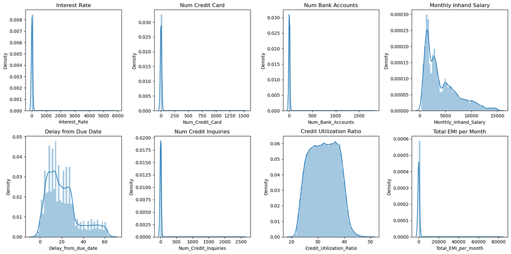

```python
fig, axes = plt.subplots(2, 4, figsize=(16, 8))

# Plot the numeric fields
sns.distplot(df['Interest_Rate'], ax=axes[0, 0])
sns.distplot(df['Num_Credit_Card'], ax=axes[0, 1])
sns.distplot(df['Num_Bank_Accounts'], ax=axes[0, 2])
sns.distplot(df['Monthly_Inhand_Salary'], ax=axes[0, 3])
sns.distplot(df['Delay_from_due_date'], ax=axes[1, 0])
sns.distplot(df['Num_Credit_Inquiries'], ax=axes[1, 1])
sns.distplot(df['Credit_Utilization_Ratio'], ax=axes[1, 2])
sns.distplot(df['Total_EMI_per_month'], ax=axes[1, 3])

#Labeling for the graphs
axes[0, 0].set_title('Interest Rate')
axes[0, 1].set_title('Num Credit Card')
axes[0, 2].set_title('Num Bank Accounts')
axes[0, 3].set_title('Monthly Inhand Salary')
axes[1, 0].set_title('Delay from Due Date')
axes[1, 1].set_title('Num Credit Inquiries')
axes[1, 2].set_title('Credit Utilization Ratio')
axes[1, 3].set_title('Total EMI per Month')

# Adjust layout
plt.tight_layout()

# Show the subplots
plt.show()
```

Key Observations:

1. Number of Bank accounts and Delay from due data columns have negative entries
2. Number of Credit cards have zero in them
3. Standardize the datapoints

```python
df['Type_of_Loan'].value_counts().head(20)
```

```
Not Specified                               1408
Credit-Builder Loan                         1280
Personal Loan                               1272
Debt Consolidation Loan                     1264
Student Loan                                1240
Payday Loan                                 1200
Mortgage Loan                               1176
Auto Loan                                   1152
Home Equity Loan                            1136
Personal Loan, and Student Loan              320
Not Specified, and Payday Loan               272
Mortgage Loan, and Home Equity Loan          264
Student Loan, and Payday Loan                256
Credit-Builder Loan, and Not Specified       248
Student Loan, and Credit-Builder Loan        248
Payday Loan, and Auto Loan                   240
Payday Loan, and Debt Consolidation Loan     240
Payday Loan, and Student Loan                232
Personal Loan, and Credit-Builder Loan       232
Mortgage Loan, and Not Specified             232
Name: Type_of_Loan, dtype: int64
```

Split the combination of the type of loan to just the main individual categories.

[figure not shown]

```python
#Plotting the Target Variable

df['Credit_Score'] = df['Credit_Score'].astype('category')

# Plot the count of each category in 'Credit Score categorization'
plt.figure(figsize=(8, 4))
sns.countplot(data=df, x='Credit_Score', palette='mako')
plt.xticks(rotation=90)  # Rotate x-axis labels for better readability
plt.xlabel('Credit_Score')
plt.ylabel('Count')
plt.title('Count of Each Occupation')
plt.show()
```

Target column is biased toward the credit score being balanced as compared to being Poor or Good

### Data Pre-Processing

These following numeric columns are being tagged as objects as they have some erroreous string characters that must be handles: 'Age', 'Annual_Income', 'Num_of_Loan', 'Num_of_Delayed_Payment', 'Changed_Credit_Limit', 'Amount_invested_monthly', 'Outstanding_Debt' , 'Monthly_Balance'

```python
columns_to_fix = ['Age', 'Annual_Income', 'Num_of_Loan', 'Num_of_Delayed_Payment',
                  'Changed_Credit_Limit', 'Amount_invested_monthly', 'Outstanding_Debt' , 'Monthly_Balance']

def fix_numbers(i):
    try :
        return float(i.replace("_",""))
    except :
        return np.nan

for cols in columns_to_fix:
    df[cols] = df[cols].apply(fix_numbers)
```

```python
df.info()
```

```
<class 'pandas.core.frame.DataFrame'>
RangeIndex: 100000 entries, 0 to 99999
Data columns (total 25 columns):
 #   Column                    Non-Null Count   Dtype
---  ------                    --------------   -----
 0   Customer_ID               100000 non-null  object
 1   Month                     100000 non-null  object
 2   Age                       100000 non-null  float64
 3   Occupation                100000 non-null  object
 4   Annual_Income             100000 non-null  float64
 5   Monthly_Inhand_Salary     84998 non-null   float64
 6   Num_Bank_Accounts         100000 non-null  int64
 7   Num_Credit_Card           100000 non-null  int64
 8   Interest_Rate             100000 non-null  int64
 9   Num_of_Loan               100000 non-null  float64
```

[output cut: 17 more lines]

```python
#Converting to Bool Values for Every type of loan
for i in df['Type_of_Loan'].value_counts().head(9).index[1:] :
    df[i] = df['Type_of_Loan'].str.contains(i)
```

```python
df.drop('Type_of_Loan',inplace=True,axis=1)
```

```python
#For a credit score to exist, the customer has to have atleast 1 credit card.

df['Num_Credit_Card'].replace(0,1,inplace=True)
```

```python
#Convert the Credit history age to credit history age in months

def credit_age_to_months(hist_age):
    # Split the string by spaces and extract years and months
    parts = str(hist_age).split()
    years = int(parts[0]) if 'Years' in parts else 0
    months = int(parts[3]) if 'Months' in parts else 0
    return (years * 12) + months

# Apply the function to the 'Age' column and create new columns
df['Years'] = df['Credit_History_Age'].apply(lambda x: credit_age_to_months(x) // 12)  # Years
df['Months'] = df['Credit_History_Age'].apply(lambda x: credit_age_to_months(x) % 12)   # Months

# Calculate the total number of months
df['Credit_history_Total_Months'] = df['Years'] * 12 + df['Months']

df = df.drop(['Years', 'Months', 'Credit_History_Age' ], axis=1)

# Display the DataFrame with the total number of months
```

```python
df.isnull().sum()
```

```
Customer_ID                        0
Month                              0
Age                                0
Occupation                         0
Annual_Income                      0
Monthly_Inhand_Salary          15002
Num_Bank_Accounts                  0
Num_Credit_Card                    0
Interest_Rate                      0
Num_of_Loan                        0
Delay_from_due_date                0
Num_of_Delayed_Payment          7002
Changed_Credit_Limit            2091
Num_Credit_Inquiries            1965
Credit_Mix                         0
Outstanding_Debt                   0
Credit_Utilization_Ratio           0
Payment_of_Min_Amount              0
Total_EMI_per_month                0
Amount_invested_monthly         4479
Payment_Behaviour                  0
Monthly_Balance                 1200
Credit_Score                       0
Credit-Builder Loan            11408
Personal Loan                  11408
Debt Consolidation Loan        11408
Student Loan                   11408
Payday Loan                    11408
Mortgage Loan                  11408
Auto Loan                      11408
Home Equity Loan               11408
Credit_history_Total_Months        0
dtype: int64
```

```python
#Checking for Null
df['Occupation'].value_counts()

#handling '______' case

for ID in df[df['Occupation'] == "_______"]['Customer_ID'] :
    oc = df[df['Customer_ID'] == ID]['Occupation'].mode()[0]
    df[df['Customer_ID'] == ID] = df[df['Customer_ID'] == ID].replace("_______",oc)

df['Occupation'].value_counts()
```

```
Lawyer           7096
Engineer         6864
Architect        6824
Mechanic         6776
Scientist        6744
Accountant       6744
Developer        6720
Media_Manager    6715
Teacher          6672
Entrepreneur     6648
Doctor           6568
Journalist       6536
Manager          6432
Musician         6352
Writer           6304
_______             5
Name: Occupation, dtype: int64
```

```python
df['Occupation'] = df['Occupation'].replace("_______",df['Occupation'].mode()[0])
df['Occupation'].value_counts()
```

```
Lawyer           7101
Engineer         6864
Architect        6824
Mechanic         6776
Scientist        6744
Accountant       6744
Developer        6720
Media_Manager    6715
Teacher          6672
Entrepreneur     6648
Doctor           6568
Journalist       6536
Manager          6432
Musician         6352
Writer           6304
Name: Occupation, dtype: int64
```

```python
df['Payment_Behaviour']= df['Payment_Behaviour'].replace("!@9#%8",np.nan)
```

```python
df['Payment_Behaviour'].value_counts()
```

```
Low_spent_Small_value_payments      25513
High_spent_Medium_value_payments    17540
Low_spent_Medium_value_payments     13861
High_spent_Large_value_payments     13721
High_spent_Small_value_payments     11340
Low_spent_Large_value_payments      10425
Name: Payment_Behaviour, dtype: int64
```

```python
df['Monthly_Inhand_Salary']
```

```
0        1824.843333
1                NaN
2                NaN
3                NaN
4        1824.843333
            ...
99995    3359.415833
99996    3359.415833
99997    3359.415833
99998    3359.415833
99999    3359.415833
Name: Monthly_Inhand_Salary, Length: 100000, dtype: float64
```

```python
from sklearn.impute import SimpleImputer

imputer = SimpleImputer(strategy="most_frequent")
imputer.fit(df[['Payment_Behaviour']])
df[['Payment_Behaviour']] = imputer.transform(df[['Payment_Behaviour']])
```

```python
#Perform Mean/Mode Imputation

#For Monthly_Inhand_Salary
df['Monthly_Inhand_Salary'] = pd.to_numeric(df['Monthly_Inhand_Salary'], errors='coerce')
mean_wages = df.groupby('Customer_ID')['Monthly_Inhand_Salary'].transform('mean')
df['Monthly_Inhand_Salary'].fillna(mean_wages, inplace=True)

#For Num_of_Delayed_Payment
df['Num_of_Delayed_Payment'] = pd.to_numeric(df['Num_of_Delayed_Payment'], errors='coerce')
mean_delay = df.groupby('Customer_ID')['Num_of_Delayed_Payment'].transform('mean')
df['Num_of_Delayed_Payment'].fillna(mean_delay, inplace=True)

#Amount_invested_monthly
df['Amount_invested_monthly'] = pd.to_numeric(df['Amount_invested_monthly'], errors='coerce')
mean_invest = df.groupby('Customer_ID')['Amount_invested_monthly'].transform('mean')
df['Amount_invested_monthly'].fillna(mean_invest, inplace=True)

#Monthly_Balance
df['Monthly_Balance'] = pd.to_numeric(df['Monthly_Balance'], errors='coerce')
mean_balance = df.groupby('Customer_ID')['Monthly_Balance'].transform('mean')
df['Monthly_Balance'].fillna(mean_balance, inplace=True)

#Changed_Credit_Limit
df['Changed_Credit_Limit'] = pd.to_numeric(df['Changed_Credit_Limit'], errors='coerce')
mean_limit = df.groupby('Customer_ID')['Changed_Credit_Limit'].transform('mean')
df['Changed_Credit_Limit'].fillna(mean_limit, inplace=True)

#For Credit Enquiries
df['Num_Credit_Inquiries'] = pd.to_numeric(df['Num_Credit_Inquiries'], errors='coerce')
mode_enquiry = df.groupby('Customer_ID')['Num_Credit_Inquiries'].apply(lambda x: x.mode().iloc[0])
df['Num_Credit_Inquiries'] = df['Customer_ID'].map(mode_enquiry)
```

```python
#Filling the Type of loan column has - where unknown
df.fillna('-',inplace=True)
```

```python
df.isna().sum()
```

```
Customer_ID                    0
Month                          0
Age                            0
Occupation                     0
Annual_Income                  0
Monthly_Inhand_Salary          0
Num_Bank_Accounts              0
Num_Credit_Card                0
Interest_Rate                  0
Num_of_Loan                    0
Delay_from_due_date            0
Num_of_Delayed_Payment         0
Changed_Credit_Limit           0
Num_Credit_Inquiries           0
Credit_Mix                     0
Outstanding_Debt               0
Credit_Utilization_Ratio       0
Payment_of_Min_Amount          0
Total_EMI_per_month            0
Amount_invested_monthly        0
Payment_Behaviour              0
Monthly_Balance                0
Credit_Score                   0
Credit-Builder Loan            0
Personal Loan                  0
Debt Consolidation Loan        0
Student Loan                   0
Payday Loan                    0
Mortgage Loan                  0
Auto Loan                      0
Home Equity Loan               0
Credit_history_Total_Months    0
dtype: int64
```

```python
df.Credit_Score.unique()
```

```
['Good', 'Standard', 'Poor']
Categories (3, object): ['Good', 'Poor', 'Standard']
```

```python
df = df[['Customer_ID', 'Month', 'Age', 'Occupation', 'Annual_Income',
       'Monthly_Inhand_Salary', 'Num_Bank_Accounts', 'Num_Credit_Card',
       'Interest_Rate', 'Num_of_Loan', 'Delay_from_due_date',
       'Num_of_Delayed_Payment', 'Changed_Credit_Limit',
       'Num_Credit_Inquiries', 'Credit_Mix', 'Outstanding_Debt',
       'Credit_Utilization_Ratio', 'Payment_of_Min_Amount',
       'Total_EMI_per_month', 'Amount_invested_monthly', 'Payment_Behaviour',
       'Monthly_Balance','Credit-Builder Loan',
       'Personal Loan', 'Debt Consolidation Loan', 'Student Loan',
       'Payday Loan', 'Mortgage Loan', 'Auto Loan', 'Home Equity Loan',
       'Credit_history_Total_Months', 'Credit_Score']]
```

```python
target = {'Good':2,
         'Standard':1,
         'Poor':0}

df['Credit_Score'] = df['Credit_Score'].map(target)
```

```python
# Define a dictionary to map full month names to month numbers
month_name_to_number = {
    'January': 1,
    'February': 2,
    'March': 3,
    'April': 4,
    'May': 5,
    'June': 6,
    'July': 7,
    'August': 8,
    'September': 9,
    'October': 10,
    'November': 11,
    'December': 12
}


df['Month'] = df['Month'].map(month_name_to_number)
```

```python
df.dtypes
```

```
Customer_ID                      object
Month                             int64
Age                             float64
Occupation                       object
Annual_Income                   float64
Monthly_Inhand_Salary           float64
Num_Bank_Accounts                 int64
Num_Credit_Card                   int64
Interest_Rate                     int64
Num_of_Loan                     float64
Delay_from_due_date               int64
Num_of_Delayed_Payment          float64
Changed_Credit_Limit            float64
Num_Credit_Inquiries            float64
Credit_Mix                       object
Outstanding_Debt                float64
Credit_Utilization_Ratio        float64
Payment_of_Min_Amount            object
Total_EMI_per_month             float64
Amount_invested_monthly         float64
Payment_Behaviour                object
Monthly_Balance                 float64
Credit-Builder Loan              object
Personal Loan                    object
Debt Consolidation Loan          object
Student Loan                     object
Payday Loan                      object
Mortgage Loan                    object
Auto Loan                        object
Home Equity Loan                 object
Credit_history_Total_Months       int64
Credit_Score                   category
dtype: object
```

```python
object_columns = df.select_dtypes(include=['object'])
```

```python
object_columns
```

|  | Customer_ID | Occupation | Credit_Mix | Payment_of_Min_Amount | Payment_Behaviour | Credit-Builder Loan | Personal Loan | Debt Consolidation Loan | Student Loan | Payday Loan | Mortgage Loan | Auto Loan | Home Equity Loan |
| --- | --- | --- | --- | --- | --- | --- | --- | --- | --- | --- | --- | --- | --- |
| 0 | CUS_0xd40 | Scientist | _ | No | High_spent_Small_value_payments | True | True | False | False | False | False | True | True |
| 1 | CUS_0xd40 | Scientist | Good | No | Low_spent_Large_value_payments | True | True | False | False | False | False | True | True |
| 2 | CUS_0xd40 | Scientist | Good | No | Low_spent_Medium_value_payments | True | True | False | False | False | False | True | True |
| 3 | CUS_0xd40 | Scientist | Good | No | Low_spent_Small_value_payments | True | True | False | False | False | False | True | True |
| 4 | CUS_0xd40 | Scientist | Good | No | High_spent_Medium_value_payments | True | True | False | False | False | False | True | True |
| ... | ... | ... | ... | ... | ... | ... | ... | ... | ... | ... | ... | ... | ... |
| 99995 | CUS_0x942c | Mechanic | _ | No | High_spent_Large_value_payments | False | False | False | True | False | False | True | False |
| 99996 | CUS_0x942c | Mechanic | _ | No | High_spent_Medium_value_payments | False | False | False | True | False | False | True | False |
| 99997 | CUS_0x942c | Mechanic | Good | No | High_spent_Large_value_payments | False | False | False | True | False | False | True | False |
| 99998 | CUS_0x942c | Mechanic | Good | No | Low_spent_Large_value_payments | False | False | False | True | False | False | True | False |
| 99999 | CUS_0x942c | Mechanic | Good | No | Low_spent_Small_value_payments | False | False | False | True | False | False | True | False |

100000 rows × 13 columns

```python
negative_age_mask = df['Age'] < 0
modes = df[~negative_age_mask].groupby('Customer_ID')['Age'].agg(lambda x: x.mode().iloc[0])
df.loc[negative_age_mask, 'Age'] = df['Customer_ID'].map(modes)
```

```python
df
```

|  | Customer_ID | Month | Age | Occupation | Annual_Income | Monthly_Inhand_Salary | Num_Bank_Accounts | Num_Credit_Card | Interest_Rate | Num_of_Loan | ... | Credit-Builder Loan | Personal Loan | Debt Consolidation Loan | Student Loan | Payday Loan | Mortgage Loan | Auto Loan | Home Equity Loan | Credit_history_Total_Months | Credit_Score |
| --- | --- | --- | --- | --- | --- | --- | --- | --- | --- | --- | --- | --- | --- | --- | --- | --- | --- | --- | --- | --- | --- |
| 0 | CUS_0xd40 | 1 | 23.0 | Scientist | 19114.12 | 1824.843333 | 3 | 4 | 3 | 4.0 | ... | True | True | False | False | False | False | True | True | 265 | 2 |
| 1 | CUS_0xd40 | 2 | 23.0 | Scientist | 19114.12 | 1824.843333 | 3 | 4 | 3 | 4.0 | ... | True | True | False | False | False | False | True | True | 0 | 2 |
| 2 | CUS_0xd40 | 3 | 23.0 | Scientist | 19114.12 | 1824.843333 | 3 | 4 | 3 | 4.0 | ... | True | True | False | False | False | False | True | True | 267 | 2 |
| 3 | CUS_0xd40 | 4 | 23.0 | Scientist | 19114.12 | 1824.843333 | 3 | 4 | 3 | 4.0 | ... | True | True | False | False | False | False | True | True | 268 | 2 |
| 4 | CUS_0xd40 | 5 | 23.0 | Scientist | 19114.12 | 1824.843333 | 3 | 4 | 3 | 4.0 | ... | True | True | False | False | False | False | True | True | 269 | 2 |
| ... | ... | ... | ... | ... | ... | ... | ... | ... | ... | ... | ... | ... | ... | ... | ... | ... | ... | ... | ... | ... | ... |
| 99995 | CUS_0x942c | 4 | 25.0 | Mechanic | 39628.99 | 3359.415833 | 4 | 6 | 7 | 2.0 | ... | False | False | False | True | False | False | True | False | 378 | 0 |
| 99996 | CUS_0x942c | 5 | 25.0 | Mechanic | 39628.99 | 3359.415833 | 4 | 6 | 7 | 2.0 | ... | False | False | False | True | False | False | True | False | 379 | 0 |
| 99997 | CUS_0x942c | 6 | 25.0 | Mechanic | 39628.99 | 3359.415833 | 4 | 6 | 5729 | 2.0 | ... | False | False | False | True | False | False | True | False | 380 | 0 |
| 99998 | CUS_0x942c | 7 | 25.0 | Mechanic | 39628.99 | 3359.415833 | 4 | 6 | 7 | 2.0 | ... | False | False | False | True | False | False | True | False | 381 | 1 |
| 99999 | CUS_0x942c | 8 | 25.0 | Mechanic | 39628.99 | 3359.415833 | 4 | 6 | 7 | 2.0 | ... | False | False | False | True | False | False | True | False | 382 | 0 |

100000 rows × 32 columns

```python
bool_cols = ['Personal Loan',
 'Debt Consolidation Loan',
 'Student Loan',
 'Payday Loan',
 'Mortgage Loan',
 'Auto Loan',
 'Home Equity Loan',
'Credit-Builder Loan']
for cols in bool_cols:
    df[cols] = df.apply(lambda x: 1 if x[cols]  else 0 ,axis=1)
```

```python
df.columns
```

```
Index(['Customer_ID', 'Month', 'Age', 'Occupation', 'Annual_Income',
       'Monthly_Inhand_Salary', 'Num_Bank_Accounts', 'Num_Credit_Card',
       'Interest_Rate', 'Num_of_Loan', 'Delay_from_due_date',
       'Num_of_Delayed_Payment', 'Changed_Credit_Limit',
       'Num_Credit_Inquiries', 'Credit_Mix', 'Outstanding_Debt',
       'Credit_Utilization_Ratio', 'Payment_of_Min_Amount',
       'Total_EMI_per_month', 'Amount_invested_monthly', 'Payment_Behaviour',
       'Monthly_Balance', 'Credit-Builder Loan', 'Personal Loan',
       'Debt Consolidation Loan', 'Student Loan', 'Payday Loan',
       'Mortgage Loan', 'Auto Loan', 'Home Equity Loan',
       'Credit_history_Total_Months', 'Credit_Score'],
      dtype='object')
```

```python
#Used for finding columns with errors

# import pandas as pd

# # Sample DataFrame with a problematic value '_'


# # Find the location of problematic value ('_') in the DataFrame
# problematic_rows = []
# problematic_columns = []

# for index, row in df.iterrows():
#     for col in df.columns:
#         value = row[col]
#         if isinstance(value, str) and value == '_':
#             problematic_rows.append(index)
#             problematic_columns.append(col)

# # Print problematic rows and columns
# for row, col in zip(problematic_rows, problematic_columns):
#     print(f"Problematic value '_' found in row {row}, column {col}")
```

```python
df[['Credit_Mix','Payment_Behaviour']]
```

|  | Credit_Mix | Payment_Behaviour |
| --- | --- | --- |
| 0 | _ | High_spent_Small_value_payments |
| 1 | Good | Low_spent_Large_value_payments |
| 2 | Good | Low_spent_Medium_value_payments |
| 3 | Good | Low_spent_Small_value_payments |
| 4 | Good | High_spent_Medium_value_payments |
| ... | ... | ... |
| 99995 | _ | High_spent_Large_value_payments |
| 99996 | _ | High_spent_Medium_value_payments |
| 99997 | Good | High_spent_Large_value_payments |
| 99998 | Good | Low_spent_Large_value_payments |
| 99999 | Good | Low_spent_Small_value_payments |

100000 rows × 2 columns

```python
imputer = SimpleImputer(strategy="most_frequent")
imputer.fit(df[['Payment_Behaviour']])
df[['Payment_Behaviour']] = imputer.transform(df[['Payment_Behaviour']])
```

```python
df.columns
```

```
Index(['Customer_ID', 'Month', 'Age', 'Occupation', 'Annual_Income',
       'Monthly_Inhand_Salary', 'Num_Bank_Accounts', 'Num_Credit_Card',
       'Interest_Rate', 'Num_of_Loan', 'Delay_from_due_date',
       'Num_of_Delayed_Payment', 'Changed_Credit_Limit',
       'Num_Credit_Inquiries', 'Credit_Mix', 'Outstanding_Debt',
       'Credit_Utilization_Ratio', 'Payment_of_Min_Amount',
       'Total_EMI_per_month', 'Amount_invested_monthly', 'Payment_Behaviour',
       'Monthly_Balance', 'Credit-Builder Loan', 'Personal Loan',
       'Debt Consolidation Loan', 'Student Loan', 'Payday Loan',
       'Mortgage Loan', 'Auto Loan', 'Home Equity Loan',
       'Credit_history_Total_Months', 'Credit_Score'],
      dtype='object')
```

```python
payment_behvaiour_replace = {

       'High_spent_Small_value_payments':1,
       'Low_spent_Large_value_payments':2,
       'Low_spent_Medium_value_payments':3,
       'Low_spent_Small_value_payments':4,
       'High_spent_Medium_value_payments':5,
       'High_spent_Large_value_payments':6 }

df['Payment_Behaviour'] = df['Payment_Behaviour'].map(payment_behvaiour_replace)
```

```python
Credit_mix_replace = {

        'Good':1,
       '-':0,
       'Bad':0}

df['Credit_Mix'] = df['Credit_Mix'].map(Credit_mix_replace)
```

```python
payment_min_replace = {

        'Yes':1,
       'NM':0,
       'No':0}

df['Payment_of_Min_Amount'] = df['Payment_of_Min_Amount'].map(payment_min_replace)
```

```python
df.dtypes
```

```
Customer_ID                      object
Month                             int64
Age                             float64
Occupation                       object
Annual_Income                   float64
Monthly_Inhand_Salary           float64
Num_Bank_Accounts                 int64
Num_Credit_Card                   int64
Interest_Rate                     int64
Num_of_Loan                     float64
Delay_from_due_date               int64
Num_of_Delayed_Payment          float64
Changed_Credit_Limit            float64
Num_Credit_Inquiries            float64
Credit_Mix                      float64
Outstanding_Debt                float64
Credit_Utilization_Ratio        float64
Payment_of_Min_Amount             int64
Total_EMI_per_month             float64
Amount_invested_monthly         float64
Payment_Behaviour                 int64
Monthly_Balance                 float64
Credit-Builder Loan               int64
Personal Loan                     int64
Debt Consolidation Loan           int64
Student Loan                      int64
Payday Loan                       int64
Mortgage Loan                     int64
Auto Loan                         int64
Home Equity Loan                  int64
Credit_history_Total_Months       int64
Credit_Score                   category
dtype: object
```

```python
df.drop('Customer_ID',inplace=True,axis=1)
```

```python
df[['Credit_Mix','Payment_Behaviour']]
```

|  | Credit_Mix | Payment_Behaviour |
| --- | --- | --- |
| 0 | NaN | 1 |
| 1 | 1.0 | 2 |
| 2 | 1.0 | 3 |
| 3 | 1.0 | 4 |
| 4 | 1.0 | 5 |
| ... | ... | ... |
| 99995 | NaN | 6 |
| 99996 | NaN | 5 |
| 99997 | 1.0 | 6 |
| 99998 | 1.0 | 2 |
| 99999 | 1.0 | 4 |

100000 rows × 2 columns

```python
df['Payment_Behaviour'].unique()
```

```
array([1, 2, 3, 4, 5, 6])
```

```python
from sklearn.preprocessing import LabelEncoder
label_encoder = LabelEncoder()
for col in ['Occupation']:
    df[col] = label_encoder.fit_transform(df[col])
```

```python
df.fillna(0,inplace=True)
```

```python
df['Credit_Mix']
```

```
0        0.0
1        1.0
2        1.0
3        1.0
4        1.0
        ...
99995    0.0
99996    0.0
99997    1.0
99998    1.0
99999    1.0
Name: Credit_Mix, Length: 100000, dtype: float64
```

```python
df.isnull().sum()
```

```
Month                          0
Age                            0
Occupation                     0
Annual_Income                  0
Monthly_Inhand_Salary          0
Num_Bank_Accounts              0
Num_Credit_Card                0
Interest_Rate                  0
Num_of_Loan                    0
Delay_from_due_date            0
Num_of_Delayed_Payment         0
Changed_Credit_Limit           0
Num_Credit_Inquiries           0
Credit_Mix                     0
Outstanding_Debt               0
Credit_Utilization_Ratio       0
Payment_of_Min_Amount          0
Total_EMI_per_month            0
Amount_invested_monthly        0
Payment_Behaviour              0
Monthly_Balance                0
Credit-Builder Loan            0
Personal Loan                  0
Debt Consolidation Loan        0
Student Loan                   0
Payday Loan                    0
Mortgage Loan                  0
Auto Loan                      0
Home Equity Loan               0
Credit_history_Total_Months    0
Credit_Score                   0
dtype: int64
```

```python
X, y = df.drop("Credit_Score",axis=1).values , df["Credit_Score"]
```

```python
X.shape
```

```
(100000, 30)
```

```python
y.shape
```

```
(100000,)
```

```python
y.value_counts(normalize=True)
```

```
1    0.53174
0    0.28998
2    0.17828
Name: Credit_Score, dtype: float64
```

```python
#Sampliing the data
from imblearn.over_sampling import SMOTE
rus = SMOTE(sampling_strategy='auto')
X_data_rus, y_data_rus = rus.fit_resample(X, y)
```

```python
y_data_rus.value_counts(normalize=True)
```

```
2    0.333333
0    0.333333
1    0.333333
Name: Credit_Score, dtype: float64
```

```python
y_data_rus = y_data_rus.astype(int)
```

```python
from sklearn.model_selection import train_test_split
X_train, X_test, y_train, y_test = train_test_split(X_data_rus, y_data_rus, test_size=0.2, random_state=42,stratify=y_data_rus)
```

Having a Train-Test split is a general practice that helps test the model on unseen data. Having a 80/20 split is a standard practice that helps retain a high number of samples for training and at the same time a small ratio that could be tested upon.

Having a larger split like 50/50 or 60/40 could result in Overfitting as the data would be not be able to categorize in the right way as the training set is too small. It would not be able to establish and maintain the data flow. Thus, generally having 70%-80% of the data reserved for training is a standard and best practice.

```python
#Standardizing the dataset - this method helps handle data with a very wide range of values (negative as well)
from sklearn.preprocessing import PowerTransformer
scalar = PowerTransformer(method='yeo-johnson', standardize=True).fit(X_train)
```

```python
X_train = scalar.transform(X_train)
X_test = scalar.transform(X_test)
```

### Implementing Logistic Regression

```python
import numpy as np
class BinaryLogisticRegressionBase:
    # private:
    def __init__(self, eta, iterations=20,C=0.001):
        self.eta = eta
        self.iters = iterations
        self.C=C
        # internally we will store the weights as self.w_ to keep with sklearn conventions

    def __str__(self):
        return 'Base Binary Logistic Regression Object, Not Trainable'

    # convenience, private and static:
    @staticmethod
    def _sigmoid(theta):
        return 1/(1+np.exp(-theta))

    @staticmethod
    def _add_intercept(X):
        return np.hstack((np.ones((X.shape[0],1)),X)) # add bias term

    # public:
    def predict_proba(self, X, add_intercept=True):
        # add bias term if requested
        Xb = self._add_intercept(X) if add_intercept else X
        return self._sigmoid(Xb @ self.w_) # return the probability y=1

    def predict(self,X):
        return (self.predict_proba(X)>0.5) #return the actual prediction



blr = BinaryLogisticRegressionBase(0.1)
print(blr)
```

```
Base Binary Logistic Regression Object, Not Trainable
```

```python
# inherit from base class
class BinaryLogisticRegression(BinaryLogisticRegressionBase):
    #private:
    def __str__(self):
        if(hasattr(self,'w_')):
            return 'Binary Logistic Regression Object with coefficients:\n'+ str(self.w_) # is we have trained the object
        else:
            return 'Untrained Binary Logistic Regression Object'

    def _get_gradient(self,X,y):
        # programming \sum_i (yi-g(xi))xi
        gradient = np.zeros(self.w_.shape) # set gradient to zero
        for (xi,yi) in zip(X,y):
            # the actual update inside of sum
            gradi = (yi - self.predict_proba(xi,add_intercept=False))*xi
            # reshape to be column vector and add to gradient
            gradient += gradi.reshape(self.w_.shape)

        return gradient/float(len(y))

    # public:
    def fit(self, X, y):
        Xb = self._add_intercept(X) # add bias term
        num_samples, num_features = Xb.shape

        self.w_ = np.zeros((num_features,1)) # init weight vector to zeros

        # for as many as the max iterations
        for _ in range(self.iters):
            gradient = self._get_gradient(Xb,y)
            self.w_ += gradient*self.eta # multiply by learning rate


blr = BinaryLogisticRegression(0.1)
print(blr)
```

```
Untrained Binary Logistic Regression Object
```

```python
%%time
# Binary Logistic Regression
params = dict(eta=0.01,
              iterations=500)

blr = BinaryLogisticRegression(**params)

# blr.fit(X_train,y_train)
# print(blr)
# yhat = blr.predict(X_test)
# print('Accuracy of: ',accuracy_score(y_test,yhat))
```

```
CPU times: user 3 µs, sys: 1e+03 ns, total: 4 µs
Wall time: 5.25 µs
```

```python
%%time
#Vectorized format
import numpy as np
from scipy.special import expit

class VectorBinaryLogisticRegression(BinaryLogisticRegression):
    # inherit from our previous class to get same functionality
    @staticmethod
    def _sigmoid(theta):
        # increase stability, redefine sigmoid operation
        return expit(theta) #1/(1+np.exp(-theta))

    # but overwrite the gradient calculation
    def _get_gradient(self,X,y):
        ydiff = y-self.predict_proba(X,add_intercept=False).ravel() # get y difference
        gradient = np.mean(X * ydiff[:,np.newaxis], axis=0) # make ydiff a column vector and multiply through

        return gradient.reshape(self.w_.shape)
```

```
CPU times: user 23 µs, sys: 1e+03 ns, total: 24 µs
Wall time: 24.1 µs
```

```python
#Multiclass Logistic Regression
class LogisticRegression:
    def __init__(self, eta, iterations=20):
        self.eta = eta
        self.iters = iterations
        # internally we will store the weights as self.w_ to keep with sklearn conventions

    def __str__(self):
        if(hasattr(self,'w_')):
            return 'MultiClass Logistic Regression Object with coefficients:\n'+ str(self.w_) # is we have trained the object
        else:
            return 'Untrained MultiClass Logistic Regression Object'

    def fit(self,X,y):
        num_samples, num_features = X.shape
        self.unique_ = np.unique(y) # get each unique class value
        num_unique_classes = len(self.unique_)
        self.classifiers_ = [] # will fill this array with binary classifiers

        for i,yval in enumerate(self.unique_): # for each unique value
            y_binary = (y==yval) # create a binary problem
            # train the binary classifier for this class
            blr = VectorBinaryLogisticRegression(self.eta,
                                                 self.iters)
            blr.fit(X,y_binary)
            # add the trained classifier to the list
            self.classifiers_.append(blr)

        # save all the weights into one matrix, separate column for each class
        self.w_ = np.hstack([x.w_ for x in self.classifiers_]).T

    def predict_proba(self,X):
        probs = []
        for blr in self.classifiers_:
            probs.append(blr.predict_proba(X)) # get probability for each classifier

        return np.hstack(probs) # make into single matrix

    def predict(self,X):
        return self.unique_[np.argmax(self.predict_proba(X),axis=1)] # take argmax along row

lr = LogisticRegression(0.1,1500)
print(lr)
```

```
Untrained MultiClass Logistic Regression Object
```

```python
#Vectorize Binary Logistic Regression
blr = VectorBinaryLogisticRegression(eta=0.01, iterations=1500)

# Prepare your training data (X_train, y_train)

# Fit the model to your training data
blr.fit(X_train, y_train)

# Make predictions on a test dataset (X_test)
y_pred = blr.predict(X_test)

# You can also get the predicted probabilities
y_probabilities = blr.predict_proba(X_test)
```

```python
print('Accuracy of: ',accuracy_score(y_test,y_pred))
```

```
Accuracy of:  0.47694718696129135
```

As Binary Logistic Regression is not the best way to clasify a multiclass problem like in our case, we get a really low accuracy

```python
lr = LogisticRegression(0.1,500)
lr.fit(X_train,y_train)
print(lr)

yhat = lr.predict(X_test)
print('Accuracy of: ',accuracy_score(y_test,yhat))
```

```
MultiClass Logistic Regression Object with coefficients:
[[-0.96604809  0.00359882 -0.0283856   0.01588821 -0.0891431  -0.07627459
  -0.02756341  0.36414891  0.22841103  0.00805235  0.48403699 -0.06210976
  -0.36897544  0.51206348  0.14753359  0.45747184  0.01264517  0.19232112
   0.01906476  0.06624283 -0.03055218  0.0831386  -0.02201871 -0.02383086
  -0.00952527  0.00652129 -0.02317276 -0.01273688  0.02670923 -0.02830248
  -0.08488341]
 [-0.82718115 -0.11523576 -0.01664097  0.00171415  0.09349521  0.04952478
   0.0100902   0.0606507  -0.08105365  0.00221277 -0.12793116  0.07013141
   0.32891726 -0.37222051 -0.94202736 -0.36688884 -0.00134933  0.11430299
  -0.20564265 -0.0386852   0.00820738 -0.00658149 -0.04125198 -0.00531297
  -0.01618309 -0.05209636 -0.01900606 -0.04632702 -0.04275354 -0.01712489
  -0.00715661]
 [-1.16944752  0.18168659  0.07228897 -0.01756337  0.02347756  0.04442218
   0.02673116 -0.39938587 -0.13583387 -0.00868663 -0.48696964  0.00564058
   0.00954529 -0.15782697  0.68545092 -0.16130952 -0.01172103 -0.41614773
   0.19458546 -0.02558592  0.02890067 -0.08443298  0.07414456  0.00842071
   0.02889329  0.04534101  0.03522101  0.08026989  0.01720383  0.03794705
   0.14428798]]
Accuracy of:  0.6958783889672465
```

```python
from sklearn.metrics import classification_report, accuracy_score
# Calculate accuracy for the batch model
accuracy_batch = accuracy_score(y_test, yhat)
print("Accuracy (Batch):", accuracy_batch)
```

```
Accuracy (Batch): 0.6958783889672465
```

As Multiclass Logistic Regression the accuracy increased to ~70%

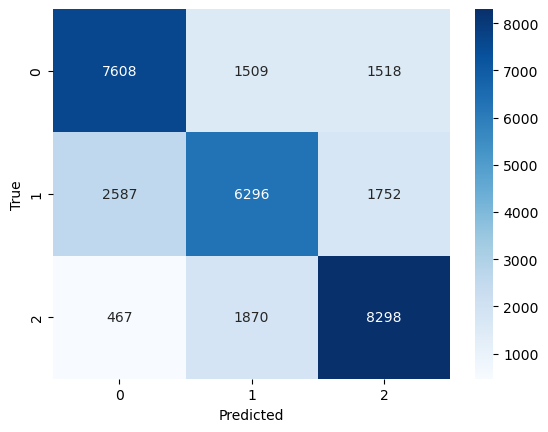

```python
import seaborn as sns
import matplotlib.pyplot as plt
from sklearn.metrics import confusion_matrix

cm = confusion_matrix(y_test, yhat)
sns.heatmap(cm, annot=True, fmt='d', cmap='Blues')
plt.xlabel('Predicted')
plt.ylabel('True')
plt.show()
```

We can observe that for all the three predicted classes, the maximum number of predictions for every class i.e 0, 1 & 2 is done correctly. Though there are good number of negatively classified cases, for the use case that helps identify and target a customer base with good credit base with offers and red flag the customers with a bad credit base, it performs pretty well. It gives us a with the right point to begin the analysis.

### Logistic Regression using Sklearn

```python
import pandas as pd
from sklearn.model_selection import train_test_split
from sklearn.preprocessing import StandardScaler
from sklearn.linear_model import LogisticRegression
from sklearn.metrics import classification_report, accuracy_score

# Create a logistic regression model
model = LogisticRegression(max_iter=1000)

# Train the model
model.fit(X_train, y_train)

# Make predictions on the test data
y_pred = model.predict(X_test)

# Evaluate the model
accuracy = accuracy_score(y_test, y_pred)
classification_rep = classification_report(y_test, y_pred)

print(f"Accuracy: {accuracy}")
print("Classification Report:\n", classification_rep)
```

```
Accuracy: 0.6949694405265633
Classification Report:
               precision    recall  f1-score   support

           0       0.72      0.70      0.71     10635
           1       0.65      0.60      0.62     10635
           2       0.72      0.78      0.75     10635

    accuracy                           0.69     31905
   macro avg       0.69      0.69      0.69     31905
weighted avg       0.69      0.69      0.69     31905
```

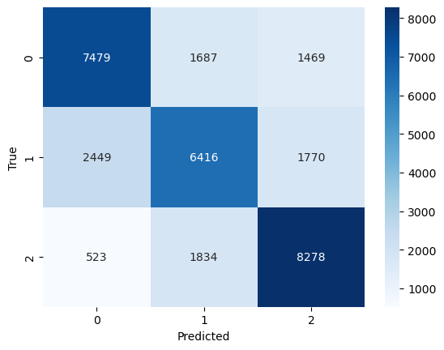

```python
cm = confusion_matrix(y_test, y_pred)
sns.heatmap(cm, annot=True, fmt='d', cmap='Blues')
plt.xlabel('Predicted')
plt.ylabel('True')
plt.show()
```

Comparing Sklearn and custom logistic regression:

Like in the case for our logistic regression model, we can see a good number of cases where the credit categories have been rightly identified. The split of negative and postive cases exisits even in this particular case.

### Logistic Regression with additional parameters and coeffecients

```python
%%time
# from last time, our logistic regression algorithm is given by (including everything we previously had):
class BinaryLogisticRegression:
    def __init__(self, eta, iterations=20, C=0.001):
        self.eta = eta
        self.iters = iterations
        self.C = C
        # internally we will store the weights as self.w_ to keep with sklearn conventions

    def __str__(self):
        if(hasattr(self,'w_')):
            return 'Binary Logistic Regression Object with coefficients:\n'+ str(self.w_) # is we have trained the object
        else:
            return 'Untrained Binary Logistic Regression Object'

    # convenience, private:
    @staticmethod
    def _add_bias(X):
        return np.hstack((np.ones((X.shape[0],1)),X)) # add bias term

    @staticmethod
    def _sigmoid(theta):
        # increase stability, redefine sigmoid operation
        return expit(theta) #1/(1+np.exp(-theta))

    # vectorized gradient calculation with regularization using L2 Norm
    def _get_gradient(self,X,y):
        ydiff = y-self.predict_proba(X,add_bias=False).ravel() # get y difference
        gradient = np.mean(X * ydiff[:,np.newaxis], axis=0) # make ydiff a column vector and multiply through

        gradient = gradient.reshape(self.w_.shape)
        gradient[1:] += -2 * self.w_[1:] * self.C

        return gradient

    # public:
    def predict_proba(self,X,add_bias=True):
        # add bias term if requested
        Xb = self._add_bias(X) if add_bias else X
        return self._sigmoid(Xb @ self.w_) # return the probability y=1

    def predict(self,X):
        return (self.predict_proba(X)>0.5) #return the actual prediction


    def fit(self, X, y):
        Xb = self._add_bias(X) # add bias term
        num_samples, num_features = Xb.shape

        self.w_ = np.zeros((num_features,1)) # init weight vector to zeros

        # for as many as the max iterations
        for _ in range(self.iters):
            gradient = self._get_gradient(Xb,y)
            self.w_ += gradient*self.eta # multiply by learning rate
            # add bacause maximizing

blr = BinaryLogisticRegression(eta=0.1,iterations=50,C=0.001)

blr.fit(X_train,y_train)
print(blr)

yhat = blr.predict(X_test)
print('Accuracy of: ',accuracy_score(y_test,yhat))
```

```
Binary Logistic Regression Object with coefficients:
[[ 2.05941613e+00]
 [ 8.59502486e-02]
 [ 1.99489452e-01]
 [-2.86986734e-02]
 [ 2.29751605e-01]
 [ 2.38151472e-01]
 [-4.45970341e-01]
 [-7.20237041e-01]
 [-6.25226736e-01]
 [-2.75461286e-02]
 [-8.35212533e-01]
 [-3.90905543e-01]
 [-1.32864037e-01]
 [-6.65264449e-01]
 [ 8.37762267e-01]
 [-5.87255933e-01]
 [ 3.41475769e-02]
 [-6.77654700e-01]
 [-6.53833877e-02]
 [ 8.04695769e-02]
 [ 4.43122433e-02]
 [ 1.83332542e-01]
 [ 1.67348670e-02]
 [-5.40953040e-03]
 [-1.10442084e-02]
 [ 7.26068140e-04]
 [ 5.66953093e-04]
 [ 7.30003661e-03]
 [-3.55647015e-02]
 [ 1.15117112e-02]
 [ 4.22199149e-01]]
Accuracy of:  0.47280990440369847
CPU times: user 2.08 s, sys: 2.29 s, total: 4.37 s
Wall time: 616 ms
```

```python
%time
# Implementing LinearSearch Logistic Regression
from scipy.optimize import minimize_scalar
import copy
from numpy import ma # (masked array) this has most numpy functions that work with NaN data.
class LineSearchLogisticRegression(BinaryLogisticRegression):

    # define custom line search for problem
    def __init__(self, line_iters=0.0, **kwds):
        self.line_iters = line_iters
        # but keep other keywords
        super().__init__(**kwds) # call parent initializer

    # this defines the function with the first input to be optimized
    # therefore eta will be optimized, with all inputs constant
    @staticmethod
    def objective_function(eta,X,y,w,grad,C):
        wnew = w - grad*eta
        g = expit(X @ wnew)
        # the line search is looking for minimization, so take the negative of l(w)
        return -np.sum(ma.log(g[y==1]))-ma.sum(ma.log(1-g[y==0])) + C*sum(wnew**2)


    def fit(self, X, y):
        Xb = self._add_bias(X) # add bias term
        num_samples, num_features = Xb.shape

        self.w_ = np.zeros((num_features,1)) # init weight vector to zeros

        # for as many as the max iterations
        for _ in range(self.iters):
            gradient = -self._get_gradient(Xb,y)
            # minimization is in opposite direction

            # do line search in gradient direction, using scipy function
            opts = {'maxiter':self.line_iters} # unclear exactly what this should be
            res = minimize_scalar(self.objective_function, # objective function to optimize
                                  bounds=(0,self.eta*10), #bounds to optimize
                                  args=(Xb,y,self.w_,gradient,self.C), # additional argument for objective function
                                  method='bounded', # bounded optimization for speed
                                  options=opts) # set max iterations

            eta = res.x # get optimal learning rate
            self.w_ -= gradient*eta # set new function values
            # subtract to minimize



lslr = LineSearchLogisticRegression(eta=1.0,
                                    iterations=6,
                                    line_iters=8,
                                    C=0.001)

lslr.fit(X_train,y_train)

yhat = lslr.predict(X_test)
print(lslr)
print('Accuracy of: ',accuracy_score(y_test,yhat))
```

```
CPU times: user 8 µs, sys: 24 µs, total: 32 µs
Wall time: 11.2 µs
Binary Logistic Regression Object with coefficients:
[[ 0.64412914]
 [ 0.02957882]
 [ 0.10702227]
 [-0.00902962]
 [ 0.13464044]
 [ 0.13948522]
 [-0.21524965]
 [-0.29000039]
 [-0.29092736]
 [-0.01466489]
 [-0.36663089]
 [-0.18671708]
 [-0.11660563]
 [-0.33512723]
 [ 0.35092113]
 [-0.30412166]
 [ 0.02861746]
 [-0.33265414]
 [-0.05599481]
 [ 0.0621021 ]
 [ 0.02322102]
 [ 0.11652878]
 [-0.00876157]
 [-0.01333587]
 [-0.01389366]
 [-0.01053874]
 [-0.01188032]
 [-0.00985942]
 [-0.02226506]
 [-0.00722448]
 [ 0.2307535 ]]
Accuracy of:  0.45281303870866635
```

```python
##Implementing Stochastic Logistic Regression
```

```python
class StochasticLogisticRegression:
    def __init__(self, eta=0.01, iterations=10, C=0.001):
        self.eta = eta
        self.iters = iterations
        self.C = C

    def __str__(self):
        if hasattr(self, "w_"):
            return (
                "Stochastic Logistic Regression with coefficients:\n"
                + str(self.w_)
            )  # is we have trained the object
        else:
            return "Untrained Stochastic Object"

    @staticmethod
    def _add_bias(X):
        return np.hstack((np.ones((X.shape[0], 1)), X))  # add bias term

    @staticmethod
    def _sigmoid(theta):
        # increase stability, redefine sigmoid operation
        return expit(theta)  # 1/(1+np.exp(-theta))

    # vectorized gradient calculation with regularization using L2 Norm
    def _get_gradient(self, X, y):
        mini_batch_size = 16
        idxs = np.random.choice(len(y), mini_batch_size)

        ydiff = y[idxs]-self.predict_proba(X[idxs],add_bias=False).ravel() # get y difference (now scalar)
        gradient = np.mean(X[idxs] * ydiff[:,np.newaxis], axis=0) # make ydiff a column vector and multiply through

        gradient = gradient.reshape(self.w_.shape)
        gradient[1:] += -2 * self.w_[1:] * self.C
        return gradient

    def predict_proba(self, X, add_bias=True):
        # add bias term if requested
        Xb = self._add_bias(X) if add_bias else X
        return self._sigmoid(Xb @ self.w_)  # return the probability y=1

    def predict(self, X):
        return self.predict_proba(X) > 0.5  # return the actual prediction

    def fit(self, X, y):
        if isinstance(X, pd.DataFrame):
            X = X.to_numpy()
        if isinstance(y, pd.Series):
            y = y.to_numpy()
        Xb = self._add_bias(X)  # add bias term
        num_samples, num_features = Xb.shape

        self.w_ = np.zeros((num_features, 1))  # init weight vector to zeros

        # for as many as the max iterations
        for ctr, _ in enumerate(range(self.iters)):
            gradient = self._get_gradient(Xb, y)
            self.w_ += gradient * self.eta  # multiply by learning rate
```

```python
# Runs the above function to include stochastic gradient descent on our logistic regression.
def run_stochastic_gradient_descent(**kwargs):
    slr = StochasticLogisticRegression(**kwargs)
    slr.fit(X_train, y_train)
    y_pred = slr.predict(X_test)

    print(f"Shape: {slr.w_.shape}")
    print(slr)
    print(f"Accuracy: {accuracy_score(y_test, y_pred) * 100:.2f}%")

run_stochastic_gradient_descent(C=0.0001, eta=0.1, iterations=20)
```

```
Shape: (31, 1)
Stochastic Logistic Regression with coefficients:
[[ 0.89625938]
 [ 0.10597294]
 [ 0.14313704]
 [-0.03576499]
 [ 0.15110978]
 [ 0.18964318]
 [-0.14830754]
 [-0.2813974 ]
 [-0.38442   ]
 [-0.08380085]
 [-0.32758784]
 [-0.32049155]
 [-0.08614048]
 [-0.44130991]
 [ 0.39634198]
 [-0.30834046]
 [ 0.07345433]
 [-0.31666748]
 [-0.08907563]
 [ 0.02764919]
 [ 0.04052535]
 [ 0.24043662]
 [-0.00773819]
 [-0.03623691]
 [-0.03228264]
 [-0.00739827]
 [ 0.0009377 ]
 [-0.13768924]
 [-0.04532909]
 [ 0.00429591]
 [ 0.15714916]]
Accuracy: 46.20%
```

```python
#BFGS Using Scipy
from scipy.optimize import fmin_bfgs # maybe the most common bfgs algorithm in the world
from numpy import ma
class BFGSBinaryLogisticRegression(BinaryLogisticRegression):

    @staticmethod
    def objective_function(w,X,y,C):
        g = expit(X @ w)
        # invert this because scipy minimizes, but we derived all formulas for maximzing
        return -ma.sum(ma.log(g[y==1]))-ma.sum(ma.log(1-g[y==0])) + C*sum(w**2)
        #-np.sum(y*np.log(g)+(1-y)*np.log(1-g))

    @staticmethod
    def objective_gradient(w,X,y,C):
        g = expit(X @ w)
        ydiff = y-g # get y difference
        gradient = np.mean(X * ydiff[:,np.newaxis], axis=0)
        gradient = gradient.reshape(w.shape)
        gradient[1:] += -2 * w[1:] * C
        return -gradient

    # just overwrite fit function
    def fit(self, X, y):
        Xb = self._add_bias(X) # add bias term
        num_samples, num_features = Xb.shape

        self.w_ = fmin_bfgs(self.objective_function, # what to optimize
                            np.zeros((num_features,1)), # starting point
                            fprime=self.objective_gradient, # gradient function
                            args=(Xb,y,self.C), # extra args for gradient and objective function
                            gtol=1e-03, # stopping criteria for gradient, |v_k|
                            maxiter=self.iters, # stopping criteria iterations
                            disp=False)

        self.w_ = self.w_.reshape((num_features,1))

bfgslr = BFGSBinaryLogisticRegression(_,iterations=3,C=0.001) # note that we need only a few iterations here

bfgslr.fit(X_train,y_train)
yhat = bfgslr.predict(X_test)
print(bfgslr)
print('Accuracy of: ',accuracy_score(y_test,yhat))
```

```
Binary Logistic Regression Object with coefficients:
[[ 0.19010581]
 [ 0.00864885]
 [ 0.05331867]
 [-0.00277627]
 [ 0.075627  ]
 [ 0.07882961]
 [-0.10819772]
 [-0.1220273 ]
 [-0.13652036]
 [-0.00770352]
 [-0.16253517]
 [-0.09444079]
 [-0.07452148]
 [-0.15792468]
 [ 0.15919384]
 [-0.1433833 ]
 [ 0.01957721]
 [-0.15939665]
 [-0.02928985]
 [ 0.03970132]
 [ 0.01313613]
 [ 0.06881462]
 [-0.0097379 ]
 [-0.00977798]
 [-0.00970113]
 [-0.00804638]
 [-0.00934029]
 [-0.00907073]
 [-0.01237056]
 [-0.00774792]
 [ 0.11466664]]
Accuracy of:  0.43786240401191034
```

```python
#BFGS from Scratch
class MultiClassLogisticRegression:
    def __init__(self, eta, iterations=20,
                 C=0.0001,
                 solver=BFGSBinaryLogisticRegression):
        self.eta = eta
        self.iters = iterations
        self.C = C
        self.solver = solver
        self.classifiers_ = []
        # internally we will store the weights as self.w_ to keep with sklearn conventions

    def __str__(self):
        if(hasattr(self,'w_')):
            return 'MultiClass Logistic Regression Object with coefficients:\n'+ str(self.w_) # is we have trained the object
        else:
            return 'Untrained MultiClass Logistic Regression Object'

    def fit(self,X,y):
        num_samples, num_features = X.shape
        self.unique_ = np.sort(np.unique(y)) # get each unique class value
        num_unique_classes = len(self.unique_)
        self.classifiers_ = []
        for i,yval in enumerate(self.unique_): # for each unique value
            y_binary = np.array(y==yval).astype(int) # create a binary problem
            # train the binary classifier for this class

            hblr = self.solver(eta=self.eta,iterations=self.iters,C=self.C)
            hblr.fit(X,y_binary)

            # add the trained classifier to the list
            self.classifiers_.append(hblr)

        # save all the weights into one matrix, separate column for each class
        self.w_ = np.hstack([x.w_ for x in self.classifiers_]).T

    def predict_proba(self,X):
        probs = []
        for hblr in self.classifiers_:
            probs.append(hblr.predict_proba(X).reshape((len(X),1))) # get probability for each classifier

        return np.hstack(probs) # make into single matrix

    def predict(self,X):
        return self.unique_[np.argmax(self.predict_proba(X),axis=1)] # take argmax along row
```

```python
%%time
lr = MultiClassLogisticRegression(eta=1.0,
                                  iterations=4,
                                  C=0.01,
                                  solver=BFGSBinaryLogisticRegression
                                 )
lr.fit(X_train,y_train)
print(lr)
```

```
MultiClass Logistic Regression Object with coefficients:
[[-8.73929639e-01 -1.08817388e-02 -3.77148593e-02  1.64861902e-02
  -4.53395307e-02 -3.09748492e-02  1.93777973e-02  2.77179085e-01
   1.85717273e-01  4.14514596e-03  3.65692971e-01 -1.84912120e-02
  -2.36285451e-01  3.47461107e-01  3.64479030e-02  3.68110052e-01
   2.19178433e-02  1.07520148e-01  7.99702381e-02  3.96688071e-02
  -1.59684906e-02  1.54428869e-02 -1.09947486e-02 -7.89935914e-03
   4.75300891e-04  1.63670922e-02  8.63703727e-05  1.89527371e-03
   2.59899569e-02 -1.11554940e-02 -1.27641993e-01]
 [-8.46157722e-01 -9.72100784e-02 -1.09110112e-02 -1.02645709e-04
   6.17497496e-02  4.25210599e-02  7.17238688e-02  3.31102424e-02
  -1.42916218e-02 -9.44550281e-04 -1.04789036e-01  1.15059869e-01
   2.79697723e-01 -2.51068690e-01 -6.26049381e-01 -3.35129822e-01
   1.69204549e-03  1.83512209e-01 -1.86690618e-01 -1.92016596e-02
   1.81314763e-02  3.30383765e-02 -4.10331975e-02 -8.99137188e-03
  -1.95251270e-02 -5.25844592e-02 -3.10527213e-02 -5.01358072e-02
  -3.98894468e-02 -2.47508360e-02  5.13217450e-02]
 [-9.58324762e-01  1.25341073e-01  6.06031922e-02 -1.66319097e-02
  -9.65802580e-03 -8.99094998e-03 -8.52464947e-02 -3.22885743e-01
  -1.78076315e-01 -2.87285286e-03 -2.98902240e-01 -9.10840842e-02
  -5.67659744e-02 -1.29463843e-01  5.46018053e-01 -8.58993801e-02
  -2.86502055e-02 -2.96737927e-01  9.42663871e-02 -1.76720580e-02
  -5.56942551e-03 -6.13503756e-02  5.30873319e-02  1.35857895e-02
   1.94042034e-02  3.53518990e-02  3.02530312e-02  5.17249136e-02
   1.30005832e-02  3.49459057e-02  9.94080623e-02]]
CPU times: user 2.04 s, sys: 680 ms, total: 2.72 s
Wall time: 538 ms
```

```python
yhat = lr.predict(X_test)
print('Accuracy of: ',accuracy_score(y_test,yhat))
```

```
Accuracy of:  0.6982291176931515
```

From Scratch: ~70%

Using Scipy: ~44%

```python
%%time
#Binary with c
class BinaryLogisticRegression:
    def __init__(self, eta, iterations=20, C=0.001):
        self.eta = eta
        self.iters = iterations
        self.C = C
        # internally we will store the weights as self.w_ to keep with sklearn conventions

    def __str__(self):
        if(hasattr(self,'w_')):
            return 'Binary Logistic Regression Object with coefficients:\n'+ str(self.w_) # is we have trained the object
        else:
            return 'Untrained Binary Logistic Regression Object'

    # convenience, private:
    @staticmethod
    def _add_bias(X):
        return np.hstack((np.ones((X.shape[0],1)),X)) # add bias term

    @staticmethod
    def _sigmoid(theta):
        # increase stability, redefine sigmoid operation
        return expit(theta) #1/(1+np.exp(-theta))

    # vectorized gradient calculation with regularization using L2 Norm
    def _get_gradient(self,X,y):
        ydiff = y-self.predict_proba(X,add_bias=False).ravel() # get y difference
        gradient = np.mean(X * ydiff[:,np.newaxis], axis=0) # make ydiff a column vector and multiply through

        gradient = gradient.reshape(self.w_.shape)
        gradient[1:] += -2 * self.w_[1:] * self.C

        return gradient

    # public:
    def predict_proba(self,X,add_bias=True):
        # add bias term if requested
        Xb = self._add_bias(X) if add_bias else X
        return self._sigmoid(Xb @ self.w_) # return the probability y=1

    def predict(self,X):
        return (self.predict_proba(X)>0.5) #return the actual prediction


    def fit(self, X, y):
        Xb = self._add_bias(X) # add bias term
        num_samples, num_features = Xb.shape

        self.w_ = np.zeros((num_features,1)) # init weight vector to zeros

        # for as many as the max iterations
        for _ in range(self.iters):
            gradient = self._get_gradient(Xb,y)
            self.w_ += gradient*self.eta # multiply by learning rate
            # add bacause maximizing

blr = BinaryLogisticRegression(eta=0.1,iterations=50,C=0.001)

blr.fit(X_train,y_train)
print(blr)

yhat = blr.predict(X_test)
print('Accuracy of: ',accuracy_score(y_test,yhat))
```

```
Binary Logistic Regression Object with coefficients:
[[ 2.05941613e+00]
 [ 8.59502486e-02]
 [ 1.99489452e-01]
 [-2.86986734e-02]
 [ 2.29751605e-01]
 [ 2.38151472e-01]
 [-4.45970341e-01]
 [-7.20237041e-01]
 [-6.25226736e-01]
 [-2.75461286e-02]
 [-8.35212533e-01]
 [-3.90905543e-01]
 [-1.32864037e-01]
 [-6.65264449e-01]
 [ 8.37762267e-01]
 [-5.87255933e-01]
 [ 3.41475769e-02]
 [-6.77654700e-01]
 [-6.53833877e-02]
 [ 8.04695769e-02]
 [ 4.43122433e-02]
 [ 1.83332542e-01]
 [ 1.67348670e-02]
 [-5.40953040e-03]
 [-1.10442084e-02]
 [ 7.26068140e-04]
 [ 5.66953093e-04]
 [ 7.30003661e-03]
 [-3.55647015e-02]
 [ 1.15117112e-02]
 [ 4.22199149e-01]]
Accuracy of:  0.47280990440369847
CPU times: user 3.04 s, sys: 2.27 s, total: 5.31 s
Wall time: 896 ms
```

```python
#Trying Regularization of terms
class VectorBinaryLogisticRegression(BinaryLogisticRegression):
    # inherit from our previous class to get same functionality
    @staticmethod
    def _sigmoid(theta):
        # increase stability, redefine sigmoid operation
        return expit(theta) #1/(1+np.exp(-theta))


    def _get_gradient(self, X, y):
        num_samples = X.shape[0]
        ydiff = y - self.predict_proba(X, add_intercept=False).ravel()

        # Compute the gradient without regularization
        gradient = np.mean(X * ydiff[:, np.newaxis], axis=0)

        if self.regularization == 'l1':
            # L1 regularization
            regularization_term = self.C * np.sign(self.w_)

        elif self.regularization == 'l2':
            # L2 regularization
            regularization_term = 2 * self.C * self.w_

        elif self.regularization == 'l1l2':
            # Both L1 and L2 regularization
            l1_term = self.C * np.sign(self.w_)
            l2_term = 2 * self.C * self.w_
            regularization_term = l1_term + l2_term

        else:
            # No regularization
            regularization_term = 0

        gradient = gradient.reshape(self.w_.shape)

        # Update the gradient with the regularization term
        gradient += regularization_term

        return gradient.reshape(self.w_.shape) / float(num_samples)
```

Deployment

Without considering any regularization terms and just using the vanilla format for multiclass logistic regression, we were able to get an accuracy of ~70%

As the results are better classified for the custom implementation of Logistic Regression, we would prefer the from scratch version over the sklearn for deployment

### References:

1. https://www.kaggle.com/code/mohamedahmed10000/credit-score-eda-prediction-multi-class/notebook
2. https://github.com/eclarson/MachineLearningNotebooks/blob/master/06.%20Optimization.ipynb
3. https://github.com/eclarson/MachineLearningNotebooks/blob/master/05.%20Logistic%20Regression.ipynb